# A Numerical Solution to the Sine-Gordon Wave Equation

Matthew Shenton

This documents purpose is to produce a working numerical solution to the Sine-Gordon equation with adequate explanation on how this was achieved.

The Sine-Gordon wave equation reads,
$$(*):\varphi_{tt}-\varphi_{xx}+\sin(\varphi)=0.$$
We will be looking more generally at the interval $x\in[a,b]$, for $a,b \in \mathbb{R}$, with the following initial conditions,
$$\varphi(x,0)=f(x), \ \frac{\partial \varphi(x,0)}{\partial t}=g(x),$$
and the no-flux boundary condition,
$$\frac{\partial \varphi}{\partial x}\bigg|_{x=a,b}=0.$$
Before going through the code, to put the alterations made to the base code given for the general wave equation into perspective, the following section goes through a rigorous mathematical explanation highlighting the logic behind these changes.

We know from basic calculus that differentiation can be expressed as
$$(1):\frac{\partial f(x,t)}{\partial x}=\lim_{h\to0}\frac{f(x+h,t)-f(x,t)}{h},$$
and as,
$$(2):\frac{\partial f(x,t)}{\partial x}=\lim_{h\to0}\frac{f(x+h,t)-f(x-h,t)}{2h},$$
for some function $f(x,t)$. Using $(1)$ to rewrite equation $(*)$ we get the following,
$$(3):\lim_{h\to0}\lim_{\tau\to0}\bigg(\frac{\varphi(x_{i},t_{j+1})-2\varphi(x_{i},t_{j})+\varphi(x_{i},t_{j-1})}{\tau^2}-\frac{\varphi(x_{i+1},t_{j})-2\varphi(x_{i},t_{j})+\varphi(x_{i-1},t_{j})}{h^2}+\sin(\varphi(x_{i},t_{j}))\bigg)=0.$$
Note the change in notation $x_{i+1}=x_{i}+h$, for simplicity, and similarly for t. Rearranging $(3)$ and dropping the limits for some finite $\tau$ and $h$, also renaming $\varphi$ to $u$ to identify that the equation is now numerical and contains some error, we get the following expression,
$$(4):u^i_{j+1}=-u^i_{j-1}+2(1-\gamma^2)u^i_{j}+\gamma^2(u^{i-1}_{j}+u^{i+1}_{j})-\tau^2\sin(u^i_{j}),$$
for $\gamma=\frac{\tau}{h}$, $i=0,1,..,N$ and $j=1, 2,...,M-1$ in the interval $t\in[0,T]$. Now for the implementation of the second initial condition we look at the virtual point $u^i_{-1}$, using the central difference formula $(2)$ we find,
$$g(x_{i})=\frac{\varphi(x_{i},t_{1})-\varphi(x_{i},t_{-1})}{2\tau}+O(\tau^2).$$
Hence, one can rewrite the last expression as,
$$\varphi(x_{i},t_{-1})=\varphi(x_{i},t_{1})-2\tau g(x_{i})+O(\tau^3),$$
or equivalently,
$$(5):u^i_{-1}=u^i_{1}-2\tau g(x_{i}).$$
Subbing equation $(5)$ into equation $(4)$ we calculate the second time row as,
$$(6):u^i_{1}=\tau g(x_{i})+(1+\gamma^2)f(x_{i})+\frac{1}{2}\gamma^2(f(x_{i-1})+f(x_{i+1}))-\frac{\tau^2}{2}\sin(f(x_{i})).$$
**GWD: I think the $(1+\gamma^2)$ should be a $(1-\gamma^2)$.**

Now to interpret our no-flux boundary condition. Using again equation (2) to rewrite the following expression we find,
$$\frac{\partial \varphi}{\partial x}\bigg|_{x=a}=0\Leftrightarrow\frac{\varphi^1_{j}-\varphi^{-1}_{j}}{2h}=0\Leftrightarrow \varphi^1_{j}=\varphi^{-1}_{j}$$
$$\frac{\partial \varphi}{\partial x}\bigg|_{x=b}=0\Leftrightarrow\frac{\varphi^{N+1}_{j}-\varphi^{N-1}_{j}}{2h}=0\Leftrightarrow \varphi^{N+1}_{j}=\varphi^{N-1}_{j}$$

One can find that equation $(6)$ can be written in a matrix form without loss of accuracy, hence the second time row can be expressed as,
$$(+):\mathbf{u_{1}}=\tau\sigma_{1}+A\mathbf{u_{0}}-\frac{\tau^2}{2}\lambda_{1},$$
where
$$\sigma_{1}=(g(a),g(x_{1}),...,g(x_{N-1}),g(b))^T$$
and
$$\lambda_{1}=(\sin(u^0_{0}),\sin(u^1_{0}),...,\sin(u^{N-1}_{0}),\sin(u^N_{0}))^T,$$
are $N+1$ dimensional vectors. Also note all emboldened characters i,e, $\mathbf{u_{0}}$ are also $N+1$ dimensional vectors, and $A$ is a tri-diagonal $N+1\times N+1$ dimensional matrix
$$A=\begin{pmatrix}
1-\gamma^2 & \boxed{\gamma^2} & 0 & \cdots & 0 \\
\frac{\gamma^2}{2} & 1-\gamma^2 & \frac{\gamma^2}{2} & \cdots & \vdots \\
0 & \frac{\gamma^2}{2} & 1-\gamma^2 & \ddots & \vdots \\
\vdots & \vdots & \ddots & \ddots & \vdots \\
0 & \cdots & \cdots & \boxed{\gamma^2} & 1-\gamma^2
\end{pmatrix}.$$
The boxed elements in the matrix represent the effects of our initial no-flux boundary conditions. From equation $(4)$ we can deduce the rest of the time rows in matrix form can be expressed as
$$(++):\mathbf{u_{j+1}}=-\mathbf{u_{j-1}}+B\mathbf{u_{j}}-\tau^2\lambda,$$
for
$$\lambda=(\sin(u^0_{j}),\sin(u^1_{j}),...,\sin(u^{N-1}_{j}),\sin(u^N_{j}))^T,$$
and $B=2A$ a square matrix.

The Sine-Gordon equation is one of the group of wave equations with soliton solutions, the 1-soliton solutions for $(*)$ are
$$\varphi_{\text{soliton}}(x,t)=4\arctan(\exp({\pm\delta(x-vt))}),$$
for
$$\delta^2=\frac{1}{1-v^2},$$
and $v$ velocity.

Solving 1-soliton solutions for our initial conditions yields the following results,
$$f(x)=4\arctan(\exp\bigg(\frac{\pm x}{\sqrt{1-v^2}}\bigg),$$
$$g(x)=-2\frac{v}{\sqrt{1-v^2}}\text{sech}\bigg(\frac{x}{\sqrt{1-v^2}}\bigg).$$
**GWD: Did you make a mistake when calculating the derivative? For $v=0$ your derivative vanishes, which can not be correct.**

Now we have our first set of initial conditions, along with our matrix representations of our time rows, $(+)$ and $(++)$, we can successfully produce the following code to numerically solve the Sine-Gordon wave equation explicitly:

```r
v=0.2
explicitWave <- function(f=function(x) 4*atan(exp(x/sqrt(1-v^2))), g=function(x)-2*(v/sqrt(1-v^2))*(1/cosh(x/sqrt(1-v^2))), a=-10, b=10, N=30, T=1, M=30) {

  # set up space grid
  h <- (b-a)/N
  x <- a + h*(0:N)

  # set up time grid
  tau <- T/M
  t <- tau*(0:M)

  # Set up evolution matrix
  gamma <- (tau/h)^2
  A <- diag(1-gamma, N+1)

  for (k in 1:N) {
    A[k,k+1] <- gamma/2
    A[k+1,k] <- gamma/2
  }
  A[1,2] <- gamma
  A[N+1,N] <- gamma

  u <- matrix(0, N+1, M+1)  # Matrix to hold the solution
  F <- function(u) sin(u)

  # Initial conditions
  u[, 1] <- f(x)  # Initial value
  u[, 2] <- A %*% u[, 1] + tau*g(x) - tau^2/2*F(u[, 1])  # eq.(4.14)

  B <- 2*A

  # Loop over time steps
  for (j in 2:M) {

    u[, j+1] <- B %*% u[, j] - u[, j-1] - tau^2 * F(u[, j])
  }


  return(list(x=x, t=t, u=u))
}
```

Arbitrarily choosing $v=0.2$, $a=-10$, $b=10$, $N=1000$, $T=10$ and $M=1500$ we generate the following plots:

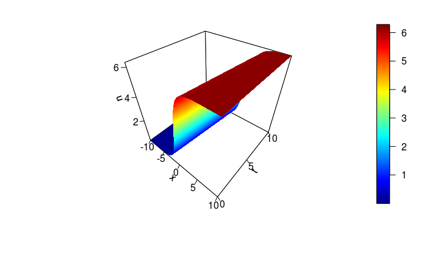

```r
sol <- explicitWave(N=1000, T=10, M=1500)
library("plot3Drgl")
persp3D(sol$x, sol$t, sol$u,
        xlab="x", ylab="t", zlab="u",
        ticktype="detailed", nticks=4)
```

,

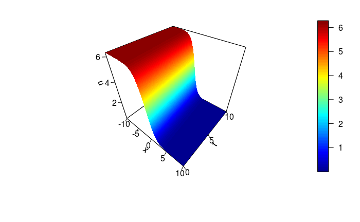

```r
sol <- explicitWave(f=function(x) 4*atan(exp(-x/sqrt(1-v^2))), N=1000, T=10, M=1500)
library("plot3Drgl")
persp3D(sol$x, sol$t, sol$u,
        xlab="x", ylab="t", zlab="u",
        ticktype="detailed", nticks=4)
```

This is exactly what [1] tells us it should look like when using 1-soliton solutions and no-flux boundary conditions.

This particular numerical scheme was fairly simple to create, however there are some quite major shortcomings. The explicit method is unstable if $h<\tau$, limiting our choices for $M,N$ and $T$. Also, the error in this method is calculated as $O(\tau^2+h^2)$, which can be improved upon e,g, $O(\tau^4+h^4)$ can be achieved (**GWD: any order can be achieved, but how practical?**). For a standard computer to run the code above took on average 5-10 minutes (**GWD: took only a few seconds on my standard computer**), for smaller time steps this would take exponentially longer (**GWD: quadratically longer**), so if one wished for greater accuracy this method would not be recommended.

As a conclusion, now we have shown using mathematical logic and evidence via comparison that the R code above is indeed correct, we will generate one last plot with what is know as the breather soliton solution for $(*)$,
$$\varphi_{B}(x,t)=4\arctan\bigg(\frac{\sqrt{1-\omega^2}\sin(\omega t)}{\omega\cosh(\sqrt{1-\omega^2}x)}\bigg).$$
Note that $\omega$ is the frequency of the oscillation, this gives us the following initial conditions,
$$f(x)=0,\ g(x)=4(\sqrt{1-\omega^2})\text{sech}(x\sqrt{1-\omega^2}).$$
Setting $\omega=0.4$ we get,

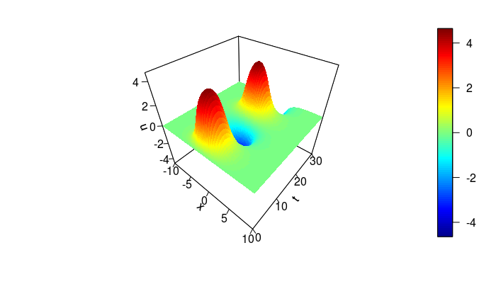

```r
w=0.4
sol <- explicitWave(f=function(x) 0*x, g=function(x) 4*sqrt(1-w^2)*(1/cosh(sqrt(1-w^2)*x)), N=80, T=30, M=500)
library("plot3Drgl")
persp3D(sol$x, sol$t, sol$u,
        xlab="x", ylab="t", zlab="u",
        ticktype="detailed", nticks=4)
```

.

Now setting $\omega=0.8$,

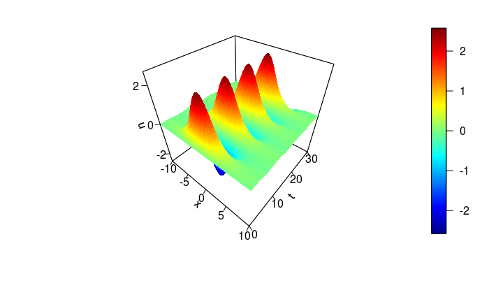

```r
w=0.8
sol <- explicitWave(f=function(x) 0*x, g=function(x) 4*sqrt(1-w^2)*(1/cosh(sqrt(1-w^2)*x)), N=80, T=30, M=500)
library("plot3Drgl")
persp3D(sol$x, sol$t, sol$u,
        xlab="x", ylab="t", zlab="u",
        ticktype="detailed", nticks=4)
```

.

As required, the code has generated the plots we wanted above. As a last note: the larger our $\omega$ the greater the frequency of the periodic spikes in the plot, as expected.

$\textbf{References}$:

[1] S. V. Gurevich. (2008). Numerical Methods for Complex Systems. Available: http://pauli.uni-muenster.de/tp/fileadmin/lehre/NumMethoden/PDE2.pdf. Last accessed 22nd Mar 2017

[2] Vladimir G. Ivancevic, Tijana T. Ivancevic. (2013). Sine-Gordon Solitons, Kinks and Breathers as Physical Models of Nonlinear Excitations in Living Cellular Structures. Available: https://arxiv.org/pdf/1305.0613.pdf. Last accessed 22nd Mar 2017.

[3] David Gablinger. (2007). Notes on The Sine Gordon Equation. Available: http://www.mathematik.uni-dortmund.de/~tdohnal/SOLIT_WAVES/SGEhandout4.pdf. Last accessed 22nd Mar 2017.